# TP3

```python
import numpy as np
import matplotlib.pyplot as plt
from scipy.stats import invwishart
from scipy import stats
from numba import jit
```

## Exercice 1

### 2.

```python
# Parameters
N = 100
k = 25

# theta

t02b, v02b = 1, 1
s_t0, s_v0 = 0.1, 0.1
v, m = 1, 7

# Fixed parameters

sigma_t0 = 0.1
sigma_v0 = 0.1
sigma_p0 = 0.1
p01b = 1
```

```python
@jit(nopython=True)
def d(t, p0, t0, v0):
    return p0 + v0 * (t - t0)
```

```python
@jit(nopython=True)
def d_all(ksi, tau, p0, t0, v0):
    val = np.zeros((N,k))
    for i in range(N):
        for j in range(k):
            t = np.exp(ksi[i]) *(j - t0 - tau[i]) + t0
            val[i,j] = d(t, p0, t0, v0)
    return val
```

```python
def init_theta0():

    t01b, v01b = np.random.normal(t02b, s_t0), np.random.normal(v02b, s_v0)

    sigma_ksi = invwishart.rvs(m, v)
    sigma_tau = invwishart.rvs(m, v)
    sigma = invwishart.rvs(m, v)
    theta0 = np.array([sigma, sigma_tau, sigma_ksi, t01b, v01b])
    return theta0
```

```python
np.random.seed(3)

### Generate theta

t01b, v01b = np.random.normal(t02b, s_t0), np.random.normal(v02b, s_v0)

sigma_ksi = invwishart.rvs(m, v)
sigma_tau = invwishart.rvs(m, v)
sigma = invwishart.rvs(m, v)

theta_true = [sigma, sigma_tau, sigma_ksi, t01b, v01b]

# Generate Zpop

p0 = np.random.normal(p01b, sigma_p0)
v0_true = np.random.normal(v01b, sigma_v0)
t0_true = np.random.normal(t01b, sigma_t0)

# Generate Zind

ksi_true = np.random.normal(0, sigma_ksi, N)
tau_true = np.random.normal(0, sigma_tau, N)
z_true = np.zeros(2*N + 2)
z_true[:N], z_true[N:2*N], z_true[-2], z_true[-1] = ksi_true, tau_true, v0_true, t0_true


Y = np.random.normal(0, sigma, size=(N,k))
Y += d_all(ksi_true, tau_true, p0, t0_true, v0_true)

theta0 = init_theta0()
```

```python
theta_true, theta0
```

```
([0.18530497501714477,
  0.5724704998784866,
  0.14963304925412016,
  1.1788628473430318,
  1.043650985051199],
 array([0.27389179, 0.1524806 , 0.74718514, 0.92625699, 1.05565162]))
```

[figure not shown]

```python
nn = 5
for i in range(1,nn):
    plt.plot(Y[i], label=f'Patient {i}')

plt.xlabel("t")
plt.ylabel("$y_i(t)$")
plt.title(f"Trajectories for {nn} patients")
plt.grid()
plt.show()
```

### 3.

#### Functions

```python
@jit(nopython=True)
def mcmc_saem(Y, theta0, kernel, target, max_iter_saem, max_iter_hm, sigma_prop, alpha = 0.6):


    ### init
    N, k = Y.shape
    Nb = max_iter_saem // 2
    S = np.zeros(5)
    z0 = np.zeros(2*N + 2)

    sigma, sigma_tau, sigma_ksi, t01b, v01b = theta0
    z0[:N] = np.random.normal(0, sigma_ksi, N)
    z0[N:2*N] = tau = np.random.normal(0, sigma_tau, N)
    z0[-2], z0[-1] = np.random.normal(v01b, sigma_v0), np.random.normal(t01b, sigma_t0)

    L_z = [z0] * (max_iter_saem + 1)
    thetas, theta = [theta0] * (max_iter_saem + 1), theta0
    acceptance = np.zeros(max_iter_saem)

    for iter in range(max_iter_saem):

        zs, accepted_rate = hasting_metropolis(L_z[iter], Y, theta, kernel, target, sigma_prop, max_iter_hm)
        z_sampled = zs[-1]
        L_z[iter + 1] = z_sampled
        if iter <= Nb:
            eps = 1
        else:
            eps = (iter - Nb) ** (-alpha)
        S += eps * (get_S(Y,z_sampled) - S)
        theta = update_theta(S, Y)
        thetas[iter + 1] = theta
        acceptance[iter] = accepted_rate

    return thetas, acceptance
```

```python
@jit(nopython=True)
def hasting_metropolis(z, Y, theta, kernel, target, sigma_prop, max_iter):


    n_accepted = 0
    zs = [z] * (max_iter + 1)
    for k in range(max_iter):

        z_sampled = kernel(zs[k], sigma_prop)
        accept = np.exp(min(0, (target(Y, z_sampled, theta) - target(Y, zs[k], theta))))
        p_ = np.random.rand()
        if p_ <= accept:
            zs[k+1] = z_sampled
            n_accepted += 1
        else:
            zs[k+1] = zs[k]

    return zs, n_accepted / max_iter
```

```python
@jit(nopython=True)
def log_target(Y, z, theta):

    #theta = [sigma, sigma_tau, sigma_ksi, t01b, v01b]
    sigma, sigma_tau, sigma_ksi, t01b, v01b = theta
    ksi, tau, v0, t0 = z[:N], z[N:2*N], z[-2], z[-1]
    val = 0
    z_d = d_all(ksi, tau, p0, t0, v0)

    val += -(1/2) * np.sum((Y - z_d)**2) / (sigma ** 2)
    val += -(1/2) * np.sum(ksi**2) / (sigma_ksi ** 2) -(1/2) * np.sum(tau**2) / (sigma_tau ** 2)
    val += - np.sum(ksi)
    val += -((t0 - t01b) ** 2) / (2 * sigma_t0 **2) -((v0 - v01b) ** 2) / (2 * sigma_v0 **2)

    return val
```

```python
@jit(nopython=True)
def get_S(Y, z):

    N, K = Y.shape
    S = np.zeros(5)
    ksi, tau, v0, t0 = z[:N], z[N:2*N], z[-2], z[-1]
    z_d = d_all(ksi, tau, p0, t0, v0)

    S[0] = (1/ (N*K)) * np.sum((Y - z_d)**2)
    S[1] = (1/ N) * np.sum(ksi**2)
    S[2] = (1/ N) * np.sum(tau**2)
    S[3] = t0
    S[4] = v0

    return S
```

```python
@jit(nopython=True)
def update_theta(S, Y):

    N, K = Y.shape
    theta = np.zeros(5)
    #theta = [sigma, sigma_tau, sigma_ksi, t01b, v01b]
    theta[0] = np.sqrt(((K*N*S[0]) - v ** 2) / (2 + m + K * N))
    theta[1] = np.sqrt((N * S[2] - v**2) / (2 + m + N))
    theta[2] = np.sqrt((N * S[1] - v**2) / (2 + m + N))
    theta[3] = ((t02b * sigma_t0 ** 2) + (S[3] * s_t0**2)) / (sigma_t0 ** 2 + s_t0 ** 2)
    theta[4] = ((v02b * sigma_v0 ** 2) + (S[4] * s_v0**2)) / (sigma_v0 ** 2 + s_v0 ** 2)

    return theta
```

```python
@jit(nopython=True)
def kernel_(z, sigma_prop):


    z_sampled = np.zeros(z.size)
    for k in range(z_sampled.size):
        z_sampled[k] = np.random.normal(z[k], sigma_prop)
    return z_sampled
```

#### Test

```python
### First test, starting from theta_true, we see if we sample around z_true
sigma_prop = 0.00045
list_z, acceptance_rate = hasting_metropolis(z_true, Y, np.array(theta_true), kernel_, log_target, sigma_prop, max_iter = 1000)
```

```python
acceptance_rate
```

```
0.298
```

```python
list_v0, list_t0 = [], []
for z in list_z:
    list_v0.append(z[-2])
    list_t0.append(z[-1])
```

```python
v0_true, t0_true
```

```
(0.9976467729849307, 1.1730707632835962)
```

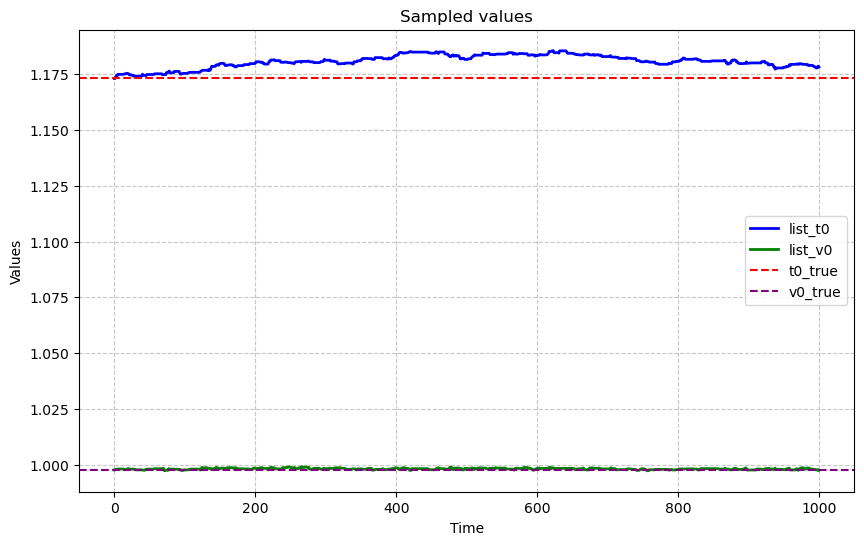

```python
plt.figure(figsize=(10, 6))
plt.plot(list_t0, label='list_t0', color='blue', linestyle='-', linewidth=2)
plt.plot(list_v0, label='list_v0', color='green', linestyle='-', linewidth=2)

plt.axhline(y=t0_true, color='red', linestyle='--', label='t0_true')
plt.axhline(y=v0_true, color='purple', linestyle='--', label='v0_true')

plt.legend()
plt.xlabel('Time')
plt.ylabel('Values')

plt.grid(True, linestyle='--', alpha=0.7)
plt.title('Sampled values')
plt.show()
```

```python
### First test, starting from theta_true, we see if we sample around z_true
sigma_prop = 0.0005
list_z, acceptance_rate = hasting_metropolis(np.zeros(2*N+2), Y, np.array(theta_true), kernel_, log_target, sigma_prop, max_iter = 100000)
```

```python
acceptance_rate
```

```
0.29276
```

```python
list_v0, list_t0 = [], []
for z in list_z:
    list_v0.append(z[-2])
    list_t0.append(z[-1])
```

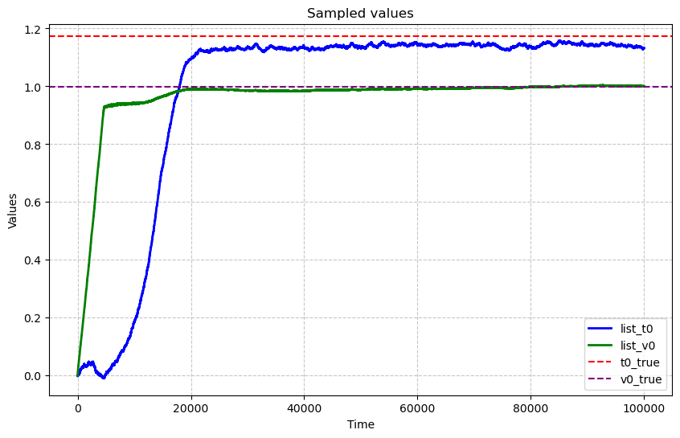

```python
plt.figure(figsize=(10, 6))
plt.plot(list_t0, label='list_t0', color='blue', linestyle='-', linewidth=2)
plt.plot(list_v0, label='list_v0', color='green', linestyle='-', linewidth=2)

plt.axhline(y=t0_true, color='red', linestyle='--', label='t0_true')
plt.axhline(y=v0_true, color='purple', linestyle='--', label='v0_true')

plt.legend()
plt.xlabel('Time')
plt.ylabel('Values')

plt.grid(True, linestyle='--', alpha=0.7)
plt.title('Sampled values')
plt.show()
```

```python
### First test, starting from theta_true, we see if we sample around z_true
sigma_prop = 0.0008
list_z, acceptance_rate = hasting_metropolis(z_true, Y, theta0, kernel_, log_target, sigma_prop, max_iter = 150000)
```

```python
acceptance_rate
```

```
0.21997333333333333
```

```python
list_v0, list_t0 = [], []
for z in list_z:
    list_v0.append(z[-2])
    list_t0.append(z[-1])
```

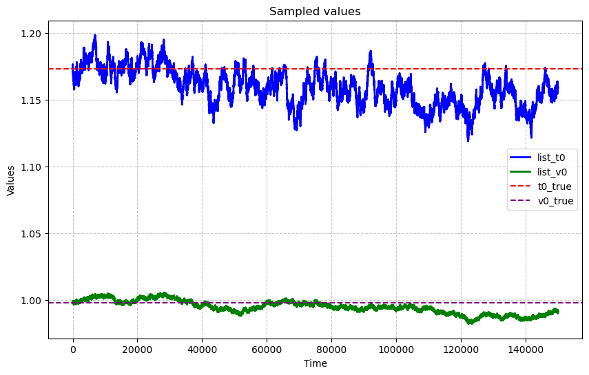

```python
plt.figure(figsize=(10, 6))
plt.plot(list_t0, label='list_t0', color='blue', linestyle='-', linewidth=2)
plt.plot(list_v0, label='list_v0', color='green', linestyle='-', linewidth=2)

plt.axhline(y=t0_true, color='red', linestyle='--', label='t0_true')
plt.axhline(y=v0_true, color='purple', linestyle='--', label='v0_true')

plt.legend()
plt.xlabel('Time')
plt.ylabel('Values')

plt.grid(True, linestyle='--', alpha=0.7)
plt.title('Sampled values')
plt.show()
```

#### Result

```python
sigma_prop = 0.00255
np.random.seed(42)
thetas, list_acceptance = mcmc_saem(Y, theta0, kernel_, log_target, max_iter_saem = 900, max_iter_hm = 1000, sigma_prop = sigma_prop, alpha = 0.5)
```

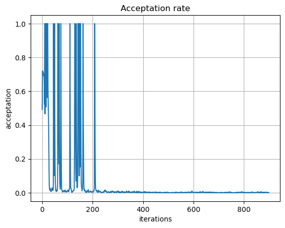

```python
plt.plot(list_acceptance)
plt.title("Acceptation rate")
plt.xlabel('iterations')
plt.ylabel('acceptation')
plt.grid()
```

```python
list_v01b, list_t01b, list_sigma, list_sigma_ksi, list_sigma_tau = [], [], [], [], []
for elem in thetas:
    list_sigma.append(elem[0])
    list_sigma_ksi.append(elem[1])
    list_sigma_tau.append(elem[2])
    list_v01b.append(elem[-2])
    list_t01b.append(elem[-1])
```

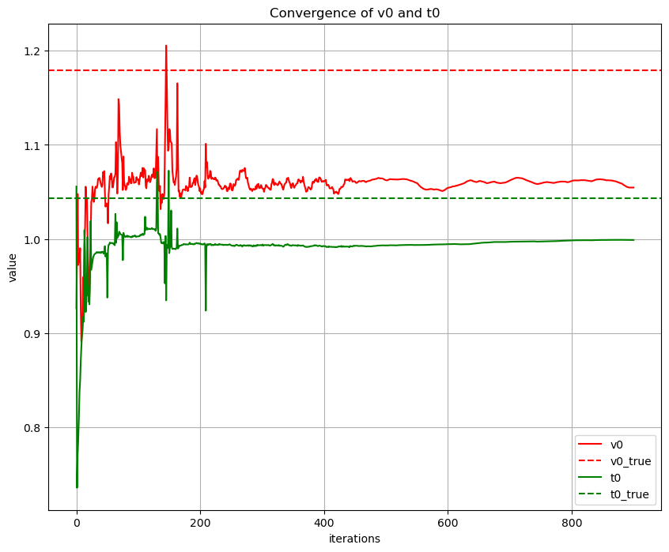

```python
plt.figure(figsize=(10,8))
plt.plot(list_v01b, color = 'red', label='v0')
plt.axhline(y=theta_true[-2], color='red', linestyle='--', label='v0_true')

plt.plot(list_t01b, color = 'green', label='t0'), theta_true[-1]
plt.axhline(y=theta_true[-1], color='green', linestyle='--', label='t0_true')
plt.title('Convergence of v0 and t0')
plt.legend()
plt.xlabel('iterations')
plt.ylabel('value')
plt.grid()
plt.show()
```

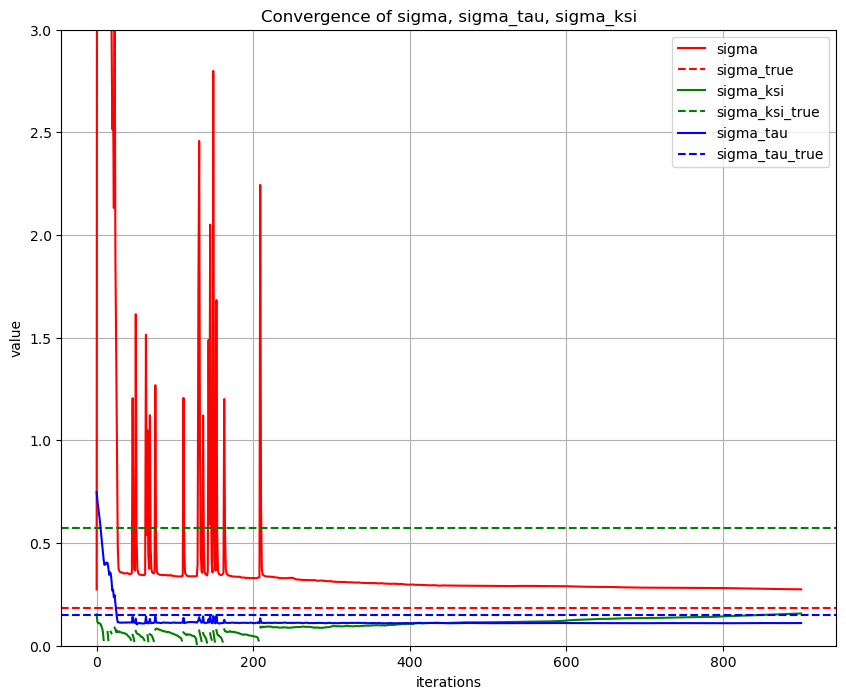

```python
plt.figure(figsize=(10,8))




plt.figure(figsize=(10,8))
plt.plot(list_sigma, label='sigma', color = 'red')
plt.axhline(y=theta_true[0], color='red', linestyle='--', label='sigma_true')

plt.plot(list_sigma_ksi, label='sigma_ksi', color = 'green')
plt.axhline(y=theta_true[1], color='green', linestyle='--', label='sigma_ksi_true')

plt.plot(list_sigma_tau, label='sigma_tau', color = 'blue')
plt.axhline(y=theta_true[2], color='blue', linestyle='--', label='sigma_tau_true')

plt.grid(True)

plt.title('Convergence of sigma, sigma_tau, sigma_ksi')
plt.legend()
plt.xlabel('iterations')
plt.ylabel('value')
plt.ylim(0,3)
plt.show()
```

```python
sigma_prop = 0.0025
np.random.seed(1)
thetas, list_acceptance = mcmc_saem(Y, theta0, kernel_, log_target, max_iter_saem = 100, max_iter_hm = 1000, sigma_prop = sigma_prop, alpha = 0.8)
```

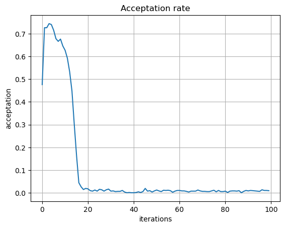

```python
plt.plot(list_acceptance)
plt.title("Acceptation rate")
plt.xlabel('iterations')
plt.ylabel('acceptation')
plt.grid()
```

```python
list_v01b, list_t01b, list_sigma, list_sigma_ksi, list_sigma_tau = [], [], [], [], []
for elem in thetas:
    list_sigma.append(elem[0])
    list_sigma_ksi.append(elem[1])
    list_sigma_tau.append(elem[2])
    list_v01b.append(elem[-2])
    list_t01b.append(elem[-1])
```

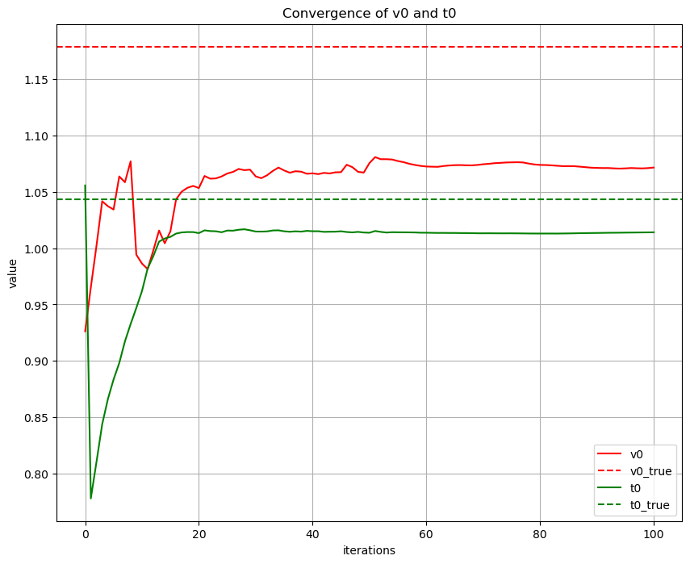

```python
plt.figure(figsize=(10,8))
plt.plot(list_v01b, color = 'red', label='v0')
plt.axhline(y=theta_true[-2], color='red', linestyle='--', label='v0_true')

plt.plot(list_t01b, color = 'green', label='t0'), theta_true[-1]
plt.axhline(y=theta_true[-1], color='green', linestyle='--', label='t0_true')
plt.title('Convergence of v0 and t0')
plt.legend()
plt.xlabel('iterations')
plt.ylabel('value')
plt.grid()
plt.show()
```

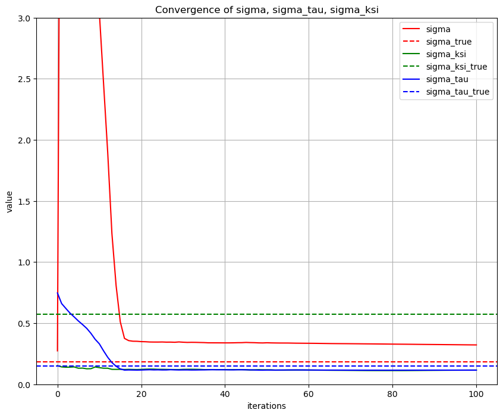

```python
plt.figure(figsize=(10,8))




plt.figure(figsize=(10,8))
plt.plot(list_sigma, label='sigma', color = 'red')
plt.axhline(y=theta_true[0], color='red', linestyle='--', label='sigma_true')

plt.plot(list_sigma_ksi, label='sigma_ksi', color = 'green')
plt.axhline(y=theta_true[1], color='green', linestyle='--', label='sigma_ksi_true')

plt.plot(list_sigma_tau, label='sigma_tau', color = 'blue')
plt.axhline(y=theta_true[2], color='blue', linestyle='--', label='sigma_tau_true')

plt.grid(True)

plt.title('Convergence of sigma, sigma_tau, sigma_ksi')
plt.legend()
plt.xlabel('iterations')
plt.ylabel('value')
plt.ylim(0,3)
plt.show()
```

Some coefficients converge to the real value, while others do not. Perhaps the algorithm's results could be improved by identifying a more suitable sigma_prop, as the acceptance rate tends towards 0, indicating minimal changes in values. The algorithm seems to be too unstable. During previous attempts, better fit could be found with a specific value of sigma_prop. One could consider implementing a function to dynamically adjust sigma_prop based on the acceptance rates from previous iterations. However, I have not attempted to implement such techniques in this context.

### 5.

We compute the new target distribution by only keeping the terms depending of $z_i$ and $z_{pop}$

```python
@jit(nopython=True)
def log_post_zi_knowing_zpop(Y, z, theta):

    N = Y.shape[0]
    idx = int(z[-1])
    assert z.size == 2*N + 3

    ksi, tau, v0, t0 = z[:N], z[N:2*N], z[2*N], z[2*N+1]
    sigma, sigma_tau, sigma_ksi, t01b, v01b = theta
    val = 0
    z_d = d_all(ksi, tau, p0, t0, v0)


    if idx < N:
        val += -(1/2) * (ksi[idx]**2) / (sigma_ksi ** 2) -ksi[i]
        val += -1/2 * np.sum((Y[idx] - z_d[idx])**2) / (sigma**2)
    else:
        val += -(1/2) * tau[idx - N]**2 / (sigma_tau ** 2)
        val += -1/2 * np.sum((Y[idx - N] - z_d[idx - N])**2) / (sigma**2)

    return val
```

```python
@jit(nopython=True)
def log_post_zpop_knowing_zi(Y, z, theta):


    N = Y.shape[0]
    idx = int(z[-1])
    assert z.size == 2*N + 3
    ksi, tau, v0, t0 = z[:N], z[N:2*N], z[2*N], z[2*N+1]
    sigma, sigma_tau, sigma_ksi, t01b, v01b = theta
    val = 0
    z_d = d_all(ksi, tau, p0, t0, v0)


    val += -1/2 * np.sum((Y - z_d)**2) / (sigma**2)
    assert (idx == 2*N) or (idx == 2*N + 1), print(idx)
    if idx == 2*N + 1:
        val +=  -((t0 - t01b) ** 2) / (2 * sigma_t0 **2)
    else:
        val += -((v0 - v01b) ** 2) / (2 * sigma_v0 **2)

    return val
```

#### function

```python
@jit(nopython=True)
def hasting_metropolis_within_gibbs(z, Y, theta, kernel, sigma_prop, max_iter, max_iter_gibs):

    N = Y.shape[0]
    zs = [z] * (max_iter + 1)
    acceptance = np.zeros(max_iter)

    for k in range(max_iter):
        acceptance_avg = 0
        z_curr = np.zeros((2*N+3))
        z_curr[:-1] = zs[k].copy()
        for idx in range((2*N+2)):
            z_curr[-1] = idx
            if idx < 2*N:
                list_z_sampled, acceptance_rate = hasting_metropolis(z_curr, Y, theta, kernel, log_post_zi_knowing_zpop, sigma_prop, max_iter_gibs)
            else:
                list_z_sampled, acceptance_rate = hasting_metropolis(z_curr, Y, theta, kernel, log_post_zpop_knowing_zi, sigma_prop, max_iter_gibs)

            z_sampled = list_z_sampled[-1]
            z_curr[idx] = z_sampled[idx]
            acceptance_avg += acceptance_rate
        acceptance_avg = acceptance_avg / (2*N+2)
        acceptance[k] = acceptance_avg
        zs[k+1] = z_curr[:-1].copy()

    return zs, acceptance
```

```python
@jit(nopython=True)
def mcmc_hmwg_saem(Y, theta0, kernel, max_iter_saem, max_iter_hm, max_iter_gibs, sigma_prop, alpha = 0.6):


    N, k = Y.shape
    Nb = max_iter_saem // 2
    S = np.zeros(5)
    z0 = np.zeros(2*N + 2)

    sigma, sigma_tau, sigma_ksi, t01b, v01b = theta0
    z0[:N] = np.random.normal(0, sigma_ksi, N)
    z0[N:2*N] = tau = np.random.normal(0, sigma_tau, N)
    z0[-2], z0[-1] = np.random.normal(v01b, sigma_v0), np.random.normal(t01b, sigma_t0)

    L_z = [z0] * (max_iter_saem + 1)
    thetas, theta = [theta0] * (max_iter_saem + 1), theta0
    acceptance = np.zeros(max_iter_saem)

    for iter in range(max_iter_saem):
        if iter % 50 == 0:
            print(iter)

        zs, accepted_rate = hasting_metropolis_within_gibbs(L_z[iter], Y, theta, kernel, sigma_prop, max_iter_hm, max_iter_gibs)
        z_sampled = zs[-1]
        L_z[iter + 1] = z_sampled
        if iter <= Nb:
            eps = 1
        else:
            eps = (iter - Nb) ** (-alpha)
        S += eps * (get_S(Y,z_sampled) - S)
        theta = update_theta(S, Y)
        thetas[iter + 1] = theta
        acceptance[iter] = np.mean(accepted_rate)

    return thetas, acceptance
```

```python
@jit(nopython=True)
def kernel_zi(z, sigma_prop):


    idx = int(z[-1])
    x = z.copy()
    x[idx] = np.random.normal(z[idx], sigma_prop)
    return x
```

```python
sigma_prop = 0.09
np.random.seed(42)
thetas, list_acceptance = mcmc_hmwg_saem(Y, theta0, kernel_zi, max_iter_saem = 500, max_iter_hm = 1, max_iter_gibs = 120, sigma_prop = sigma_prop, alpha = 0.65)
```

```
0
50
100
150
200
250
300
350
400
450
```

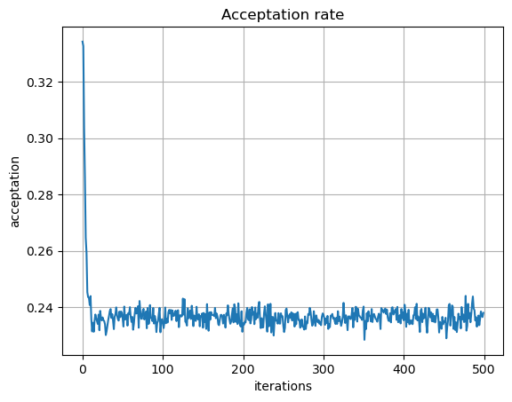

```python
plt.plot(list_acceptance)
plt.title("Acceptation rate")
plt.xlabel('iterations')
plt.ylabel('acceptation')
plt.grid()
```

```python
list_v01b, list_t01b, list_sigma, list_sigma_ksi, list_sigma_tau = [], [], [], [], []
for elem in thetas:
    list_sigma.append(elem[0])
    list_sigma_ksi.append(elem[1])
    list_sigma_tau.append(elem[2])
    list_v01b.append(elem[-2])
    list_t01b.append(elem[-1])
```

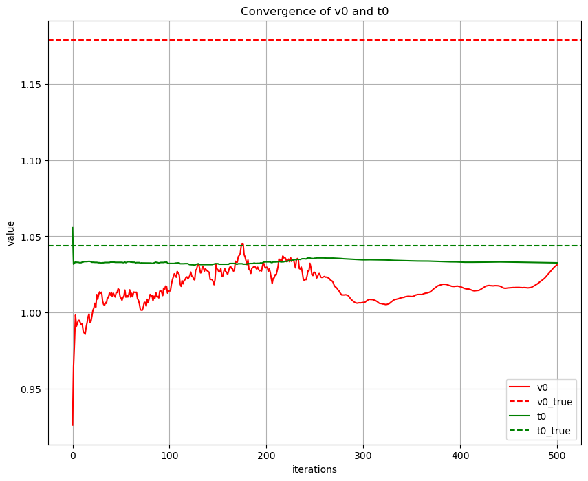

```python
plt.figure(figsize=(10,8))
plt.plot(list_v01b, color = 'red', label='v0')
plt.axhline(y=theta_true[-2], color='red', linestyle='--', label='v0_true')

plt.plot(list_t01b, color = 'green', label='t0'), theta_true[-1]
plt.axhline(y=theta_true[-1], color='green', linestyle='--', label='t0_true')
plt.title('Convergence of v0 and t0')
plt.legend()
plt.xlabel('iterations')
plt.ylabel('value')
plt.grid()
plt.show()
```

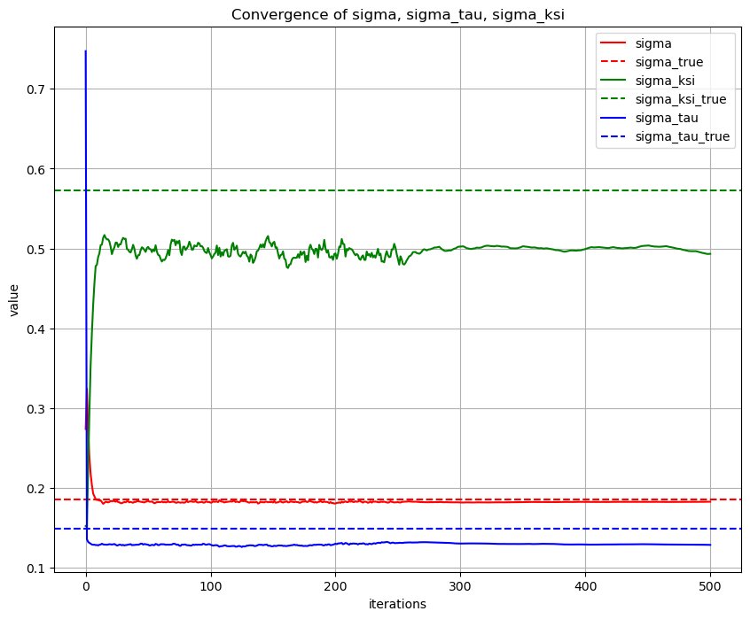

```python
plt.figure(figsize=(10,8))




plt.figure(figsize=(10,8))
plt.plot(list_sigma, label='sigma', color = 'red')
plt.axhline(y=theta_true[0], color='red', linestyle='--', label='sigma_true')

plt.plot(list_sigma_ksi, label='sigma_ksi', color = 'green')
plt.axhline(y=theta_true[1], color='green', linestyle='--', label='sigma_ksi_true')

plt.plot(list_sigma_tau, label='sigma_tau', color = 'blue')
plt.axhline(y=theta_true[2], color='blue', linestyle='--', label='sigma_tau_true')

plt.grid(True)

plt.title('Convergence of sigma, sigma_tau, sigma_ksi')
plt.legend()
plt.xlabel('iterations')
plt.ylabel('value')
plt.show()
```

#### 8.

Undoubtedly, the Gibbs sampler introduces numerous computational steps. Therefore, parallelizing these calculations emerges as an effective strategy to enhance the overall execution speed of the code.

## Exercise 2

We will sample the exponential which inverse cdf can be computed, and the Cauchy distribution which cdf cannot be inversed to illustrate this exercice.

```python
def hasting(z0, cdf, max_iter):
    curr_z = z0

    for _ in range(max_iter):
        proposed_z = kernel(curr_z)
        p_ = np.random.rand()

        if p_< alpha(curr_z, proposed_z, cdf):
            curr_z = proposed_z

    return curr_z
```

```python
def kernel(x):
    eps = np.random.uniform(-1, 1)
    B = np.random.binomial(1, 1/2)
    if B == 1:
        return eps*x
    else:
        return x/eps

def alpha(x, y, cdf):
        return min(1, abs(y/ x) *cdf(y) / cdf(x))
```

```python
def cdf1(x):
    return stats.expon.pdf(x, 1, 5)

cauchy_distribution = stats.cauchy(loc=0, scale=1)
def cdf2(x):
    return cauchy_distribution.pdf(x)
```

```python
L_x = [hasting(1, cdf1, 120) for _ in range(1000)]

x_ax = np.linspace(min(L_x), max(L_x), 100)
true_distrib = cdf1(x_ax)
```

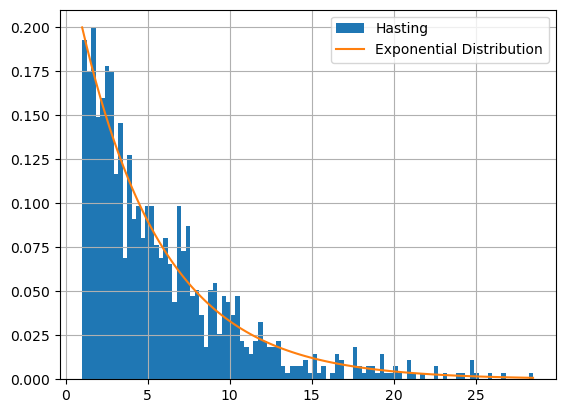

```python
plt.hist(L_x, bins=100, label="Hasting", density=True)
plt.plot(x_ax, true_distrib, label = "Exponential Distribution")
plt.legend()
plt.grid()
```

```python
L_x = [hasting(1, cdf2, 120) for _ in range(1000)]

x_ax = np.linspace(min(L_x), max(L_x), 100)
true_distrib = cdf2(x_ax)
```

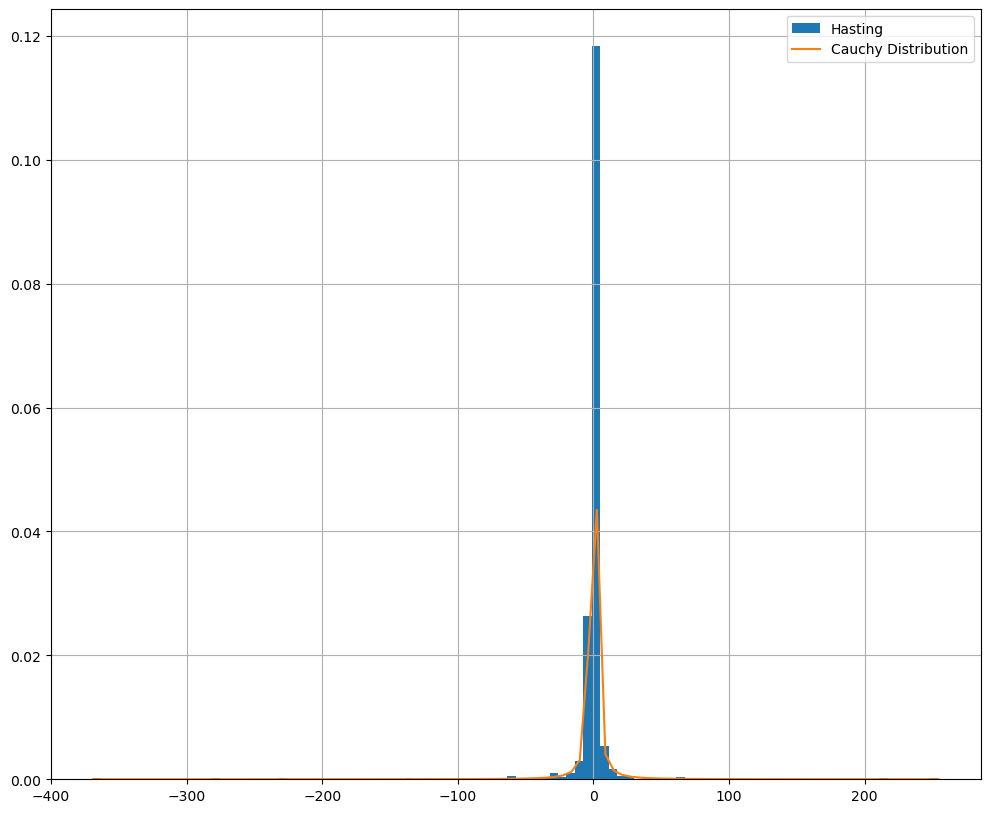

```python
plt.figure(figsize=(12,10))
plt.hist(L_x, bins=100, label="Hasting", density=True)
plt.plot(x_ax, true_distrib, label = "Cauchy Distribution")
plt.legend()
plt.grid()
```